# Machine Learning Fundamental(sklearn)

## Machine Learning Summary:

Machine Learning is about making machines get better at some task by learning from data, instead of having to explicitly code rules.There are many different types of ML systems: supervised or not, batch or online, instance based or model-based.

In an ML project you gather data in a training set, and you feed the training set to a learning algorithm. If the algorithm is model-based, it tunes some parameters to fit the model to the training set (i.e., to make good predictions on the training set itself), and then hopefully it will be able to make good predictions on new cases as well. If the algorithm is instancebased, it just learns the examples by heart and generalizes to new instances by using a similarity measure to compare them to the learned instances.

The system will not perform well if your training set is too small, or if the data is not representative, is noisy, or is polluted with irrelevant features (garbage in, garbage out). Lastly, your model needs to be neither too simple (in which case it will underfit) nor too complex (in which case it will overfit).

Some of the *main challenges* in Machine Learning are the lack of data, poor data quality, nonrepresentative data, uninformative features, excessively simple models that underfit the training data, and excessively complex models that overfit the data.

#### ML Project process (8 main steps)

1. Frame the problem and look at the big picture.
   - Define the objective in business terms
   - How to frame problem (supervised/unsupervised, online/offline, etc.)?
   - How should performance be measured?
   - What would be the minimum performance needed to reach the business objective?
   - List and verify assumptions (eg. when predict age, whether business team need actual age or grouping age like young, adult, old ,etc?)
2. Get the data.
   - List the data you need and how much you need.
   - Convert the data to a format you can easily manipulate
   - Check the size and type of data (time series, sample, geographical, etc.).
   - Sample a test set, put it aside, and never look at it (no data snooping!).
3. Explore the data to gain insights.
   - Sampling down data for exploration
   - Study each attribute and its characteristics:
     - Name
     - Type (categorical, int/float, bounded/unbounded, text, structured, etc.)
     - % of missing values
     - Noisiness and type of noise (stochastic, outliers, rounding errors, etc.)
     - Type of distribution (Gaussian, uniform, logarithmic, etc.)
   - Visualize the data
   - Study the correlations between attributes
4. Prepare the data to better expose the underlying data patterns to Machine Learning algorithms. Work on copies of the data (keep the original indices intact).
   - Data cleaning (Deal with outliers and missing values)
   - Feature selection (Drop no useful information, features)
   - Feature engineering
     - Discretize continuous features, if needed (eg group age into age range)
     - Decompose features (e.g., categorical, date/time in to year day, etc.).
     - Add promising transformations of features (e.g., log(x), sqrt(x), x , etc.).
     - Aggregate features into promising new features
     - Standardize or normalize features
5. Explore many different models and shortlist the best ones. (Maybe sample smaller size to able to train diff model in reasonable time
   - Train many quick-and-dirty models from different categories (e.g., linear, naive Bayes, SVM, Random Forest, neural net, etc.) using standard parameters.
   - Measure and compare their performance. For each model, use N-fold cross-validation and compute the mean and standard deviation of the performance measure on the N K.
   - Analyze the most significant variables(features) for each algorithm
   - Analyze the types of errors the models make
   - Perform a quick round of feature selection and engineering
   - Perform one or two more quick iterations of the five previous steps
   - Shortlist the top three to five most promising models, preferring models that make different types of errors.
6. Fine-tune your models and combine them into a great solution.
   - Fine-tune the hyperparameters using cross-validation: Unless there are very few hyperparameter values to explore, prefer random search over grid search. If training is very long, you may prefer a Bayesian optimization approach
   - Try Ensemble methods. Combining your best models will often produce better performance than running them individually.
   - Once you are confident about your final model, measure its performance on the test set to estimate the generalization error.
7. Present your solution.
   - Explain why your solution achieves the business objective
   - Don’t forget to present interesting points you noticed along the way
   - Ensure your key findings are communicated through beautiful visualizations or easy-to remember statements
8. Launch, monitor, and maintain your system
   - Write monitoring code to check your system’s live performance at regular intervals and trigger alerts when it drops.
   - Retrain your models on a regular basis on fresh data

## Project : US Real Estate data

### 1. Frame the problem

```
- Predict real estate price based on given features (hence, regression task)
- Typically measure by RMSE. Or if there are many outliers, you may consider using the mean absolute error MAE
```

```python
import numpy as np
import pandas as pd
import matplotlib.pyplot as plt
import seaborn as sns
sns.set_style("ticks")
```

```python
import pandas as pd
housing = pd.read_csv('MLSKindices/housing.csv')
housing.head(3)
```

|  | longitude | latitude | housing_median_age | total_rooms | total_bedrooms | population | households | median_income | median_house_value | ocean_proximity |
| --- | --- | --- | --- | --- | --- | --- | --- | --- | --- | --- |
| 0 | -122.23 | 37.88 | 41.0 | 880.0 | 129.0 | 322.0 | 126.0 | 8.3252 | 452600.0 | NEAR BAY |
| 1 | -122.22 | 37.86 | 21.0 | 7099.0 | 1106.0 | 2401.0 | 1138.0 | 8.3014 | 358500.0 | NEAR BAY |
| 2 | -122.24 | 37.85 | 52.0 | 1467.0 | 190.0 | 496.0 | 177.0 | 7.2574 | 352100.0 | NEAR BAY |

```python
housing.info()
```

```
<class 'pandas.core.frame.DataFrame'>
RangeIndex: 20640 entries, 0 to 20639
Data columns (total 10 columns):
longitude             20640 non-null float64
latitude              20640 non-null float64
housing_median_age    20640 non-null float64
total_rooms           20640 non-null float64
total_bedrooms        20433 non-null float64
population            20640 non-null float64
households            20640 non-null float64
median_income         20640 non-null float64
median_house_value    20640 non-null float64
ocean_proximity       20640 non-null object
dtypes: float64(9), object(1)
memory usage: 1.6+ MB
```

```python
housing.ocean_proximity.value_counts() # we can see that it is categorical variables
```

```
<1H OCEAN     9136
INLAND        6551
NEAR OCEAN    2658
NEAR BAY      2290
ISLAND           5
Name: ocean_proximity, dtype: int64
```

### 3. Explore the data to gain insights.

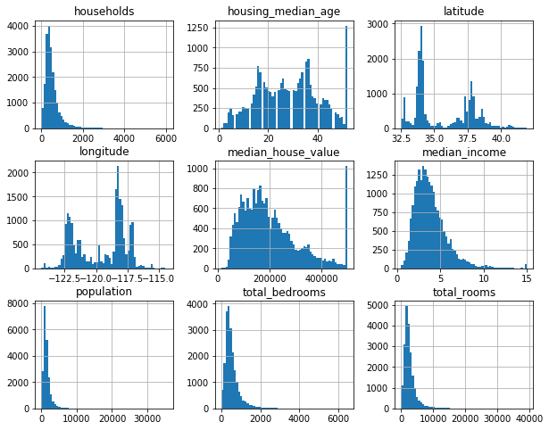

```python
%matplotlib inline
import matplotlib.pyplot as plt
housing.hist(bins=60,figsize= (10,8))
plt.show;
```

Notice from hist that

1. median_income is in preprocess form (0-15). So it is actually in 10k scale meaning 3 = 30,000 USD
2. housing_median_age and median_house_value are cap
3. these features have very different scale some 0-15 some 0-400k
4. most all are tail heavy. (maybe try to transform to bell-shaped)

#### Create test set

```python
from sklearn.model_selection import train_test_split
train_set, test_set = train_test_split(housing , test_size = 0.2,random_state = 42)
train_set.shape, test_set.shape
```

```
((16512, 11), (4128, 11))
```

But we know that income is highly affect house_value so we try to stratified sampling of every income so that training set represent all type of income  
Create categorical variable of 5 income range from continuous income

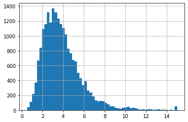

```python
housing.median_income.hist(bins = 60);
```

```python
med_income = pd.cut(housing.median_income, [0,1.5,3,4.5,6,np.inf])
round(housing.pivot_table('median_house_value', index = med_income),1)
# the greater the income the higher the house value
```

| median_income | median_house_value |
| --- | --- |
| (0.0, 1.5] | 112125.2 |
| (1.5, 3.0] | 136544.1 |
| (3.0, 4.5] | 199613.3 |
| (4.5, 6.0] | 258290.0 |
| (6.0, inf] | 378671.2 |

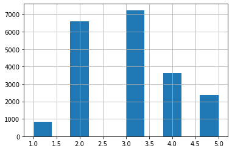

```python
# add new feature to df
housing['income_cat'] = pd.cut(housing.median_income, [0,1.5,3,4.5,6, np.inf],
                               labels=[1,2,3,4,5]) # label so that it become numeric value 1-5 instead of (0.0, 1.5]
housing.income_cat.hist();
```

Create stratified sampling based on the income category

```python
from sklearn.model_selection import StratifiedShuffleSplit

split = StratifiedShuffleSplit(n_splits=1,test_size=0.2, random_state=42)
for train_index , test_index in split.split(housing, housing['income_cat']):
    strat_train_set = housing.loc[train_index]
    strat_test_set = housing.loc[test_index]
```

```python
# see if  the income propotion in test set is equal to train set and overall set
strat_test_set['income_cat'].value_counts()/len(strat_test_set)
```

```
3    0.350533
2    0.318798
4    0.176357
5    0.114583
1    0.039729
Name: income_cat, dtype: float64
```

```python
sta_tmp1 =  strat_test_set['income_cat'].value_counts()/len(strat_test_set)
sta_tmp2 =  strat_train_set['income_cat'].value_counts()/len(strat_train_set)
rand_split_train = train_set['income_cat'].value_counts()/len(train_set)
round(pd.DataFrame({'Stratified_train set' :sta_tmp1,
              'Stratified_test set' :sta_tmp2,
              'random split' : rand_split_train}),4)
# see that random split from train_test_split have mismath propotion
```

|  | Stratified_train set | Stratified_test set | random split |
| --- | --- | --- | --- |
| 3 | 0.3505 | 0.3506 | 0.3486 |
| 2 | 0.3188 | 0.3189 | 0.3175 |
| 4 | 0.1764 | 0.1763 | 0.1785 |
| 5 | 0.1146 | 0.1144 | 0.1157 |
| 1 | 0.0397 | 0.0398 | 0.0397 |

```python
#remove income_cat back to original state
strat_test_set.drop('income_cat',axis='columns',inplace= True)
strat_train_set.drop('income_cat',axis='columns',inplace= True)
```